# DSIC PRESENTATION slides

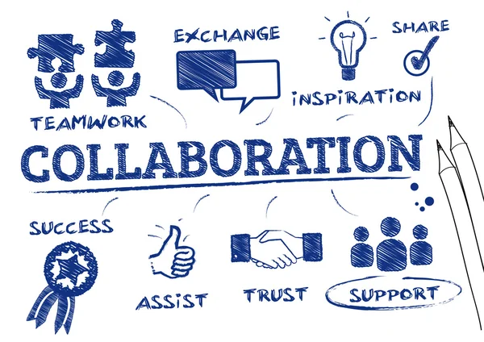

## IN...

### I. **Introduction**, *Git, GitHub, Version Control*

### II. **Key Features**, *Branches, Pulls, Collaborative Dev Models*

### III. **Communicating in GitHub**, *Issues, Discussions*

### IV. **Integration**, *Text Editors, GitHub Desktop, RStudio*

### V. **Resources**, *Helpful links*

### VI. **Q & A**, *Closing Remarks*

# Introduction

## What is Git?

“Git is an open-source version control system created by Linus Torvalds in 2005.

Specifically, Git is a distributed version control system, which means that the entire  
codebase and history is available on every developer’s computer, which allows for easy  
branching and merging.

According to a Stack Overflow developer survey, over 87% of developers use Git.”

Source: https://kinsta.com/knowledgebase/what-is-github/

## Why is Version Control Important?

The basic documentation of all code work, managing and tracking changes,  
allows developers and teams to maintain code integrity and the ability  
to track and revert to changes.

## What is Git*Hub*?

## What is GitHub (cont'd)

Git-Hub is a cloud-based repository service.

## What is GitHub (cont'd)

Not just for Data Science!

As of June 2022:

- 83m developers
- 200m+ repositories
- 337 programming languages

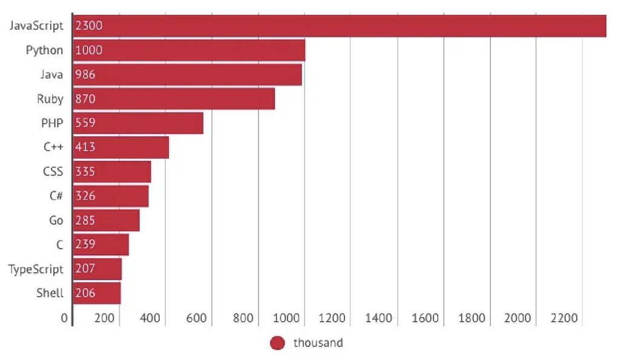

Source: https://www.rankred.com/facts-and-statistics-about-github/ (2018)

## Why GitHub?

GitHub offers powerful tools combining useful, well-known  
features from some of the most popular applications in use  
today in an environment that encourages collaboration,  
communication, and clearly documented work.

## Why GitHub? (cont'd)

As the most popular and widely-used repository  
amongst developers, collaborating in GitHub is an essential  
skill in the workplace and for aspiring writers of better code.

# Key Features

## Branches

## Branches (cont'd)

- Allow different versions of projects at one time
- Main branch = *definitive version*
- Each branch represents a set of related changes

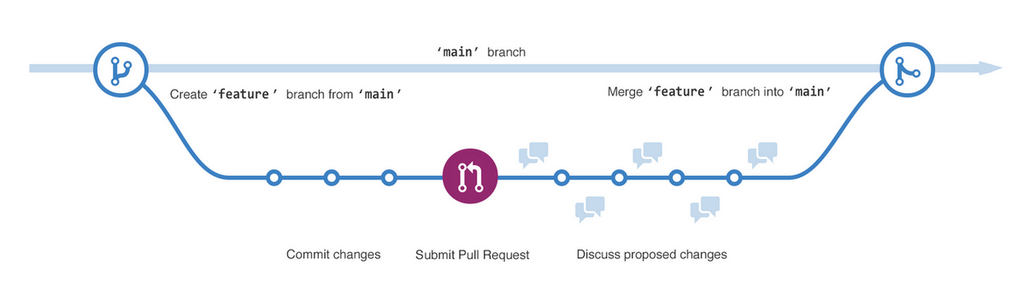

Source: [GitHub](https://docs.github.com/en/get-started/quickstart/hello-world)

## Branches (cont'd)

[figure not shown]

## Pull Requests (PR)

- The "heart of collaboration in GitHub"
- Propose changes and request review and approval
- Should be made to branches of the repository
- Final branches merged to main and deleted

## PR (cont'd)

[figure not shown]

## Collaborative Development Models

### Fork and Pull Model

Fork (copy) an existing repository and push changes to the forked (copied) repo.

- Popular with open-source projects
- Allows people to work independently without upfront coordination
- Opening a pull request to the fork allows anyone with push access to the upstream repo to make comments or changes,
- No permission needed from source repo

### Shared Repository Model

Collaborators are granted push access to a single, shared repository.

- Topic branches are created when changes need to be made.
- Pull requests initiate code review and general discussion about a set of changes before the changes are merged into the main development branch.
- Popular with small teams and collaborating on private projects.

# Communicating in GitHub

## Issues

## Issues (cont'd)

GitHub "Issues" lets you identify, track, assign, and resolve tasks.

- Task lists
- Labels
- Milestones
- Notifications

For more information: https://docs.github.com/en/issues/tracking-your-work-with-issues/about-issues

## Issues (cont'd)

[figure not shown]

## Issues (cont'd)

- @mention collaborators who have access to your repository in an issue to draw their attention to a comment
- To link related issues in the same repository, you can type # followed by part of the issue title and then clicking the issue that you want to link
- Assign issues to communicate responsibility
- Use saved replies

For more on GitHub issues, visit https://docs.github.com/en/issues/tracking-your-work-with-issues/about-issues

## Discussions

## Discussions (cont'd)

- Allow you to communicate with your group within a repository but outside of issues.
- New issues may be created and assigned from Discussions

## Discussions (cont'd)

[figure not shown]

# Integration

## Integration (cont'd)

Allows you to make pull requests or push work directly to GitHub

- Text Editors (Atom, Sublime)
- GitHub Desktop
- RStudio

# Resources

## Resources (cont'd)

https://www.youtube.com/githubguides  
https://skills.github.com/  
https://docs.github.com/  
https://campus.datacamp.com/courses/github-concepts/introduction-to-github